# Stat 461 Final Project

Roshan Poduval

12/6/2020

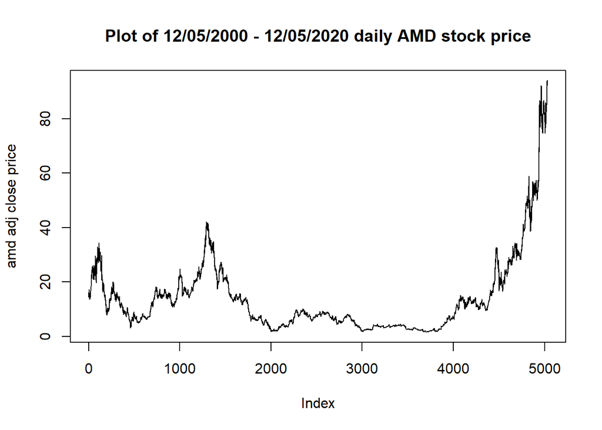

```r
amd_price = read.table("AMD.csv", sep=",", header=TRUE)
amd_price = amd_price$Adj.Close
plot(amd_price, type='l', ylab="amd adj close price", main="Plot of 12/05/2000 - 12/05/2020 daily AMD stock price")
```

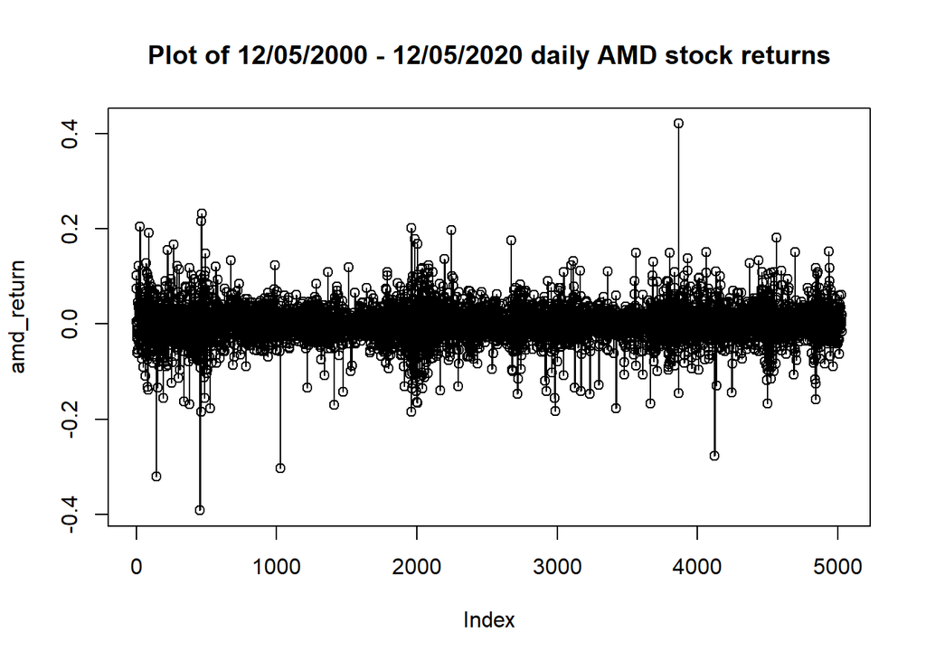

```r
amd_return = diff(log(amd_price)) # daily log returns
plot(amd_return, type="o", main="Plot of 12/05/2000 - 12/05/2020 daily AMD stock returns")
```

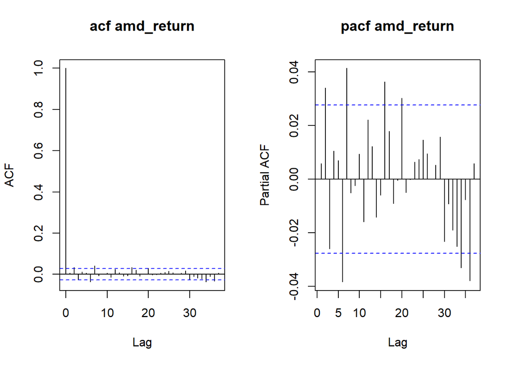

```r
par(mfrow=c(1,2))
acf(amd_return, main="acf amd_return")
pacf(amd_return, main="pacf amd_return")
```

From the acf and pacf plots of the AMD log returns, it looks like there is some correlation in the lags of the non-squared term.

```r
mean(amd_return)
```

```
## [1] 0.000372543
```

```r
sd(amd_return)
```

```
## [1] 0.03923543
```

```r
skewness(amd_return)
```

```
## [1] -0.1897285
```

```r
kurtosis(amd_return)
```

```
## [1] 12.57562
```

I will perform a two-sided t-test to check if the mean of the AMD log returns is different from 0.

```r
t.test(amd_return, mu=0, alternative="two.sided")
```

```
##
##  One Sample t-test
##
## data:  amd_return
## t = 0.67341, df = 5029, p-value = 0.5007
## alternative hypothesis: true mean is not equal to 0
## 95 percent confidence interval:
##  -0.0007120008  0.0014570867
## sample estimates:
##   mean of x
## 0.000372543
```

```r
Box.test(amd_return, lag=20, type="Ljung-Box")
```

```
##
##  Box-Ljung test
##
## data:  amd_return
## X-squared = 43.998, df = 20, p-value = 0.001506
```

The mean of the returns does not appear to be significantly different from 0 (no need for MA model), and there appears to be some correlation in the lags of the non-squared term (seen in the acf and pacf plots and by performing the Ljung-Box test on the AMD log returns). This tells me that I might want to consider employing an AR model.

I will be checking AIC and BIC to determine how many lags I should use for the AR model.

```r
#testing_ar = 20
#aic = matrix(rep(0, testing_ar), testing_ar, 1)
#bic = matrix(rep(0, testing_ar), testing_ar, 1)
#for (i in 1:testing_ar) {
#  m = arima(amd_return, order=c(i,0,0))
#  aic[i,1] = AIC(m)
#  bic[i,1] = BIC(m)
#}
#which(aic== min(aic), arr.ind = TRUE) # [7, 1] {ARIMA(7,0,0)}
#which(bic== min(bic), arr.ind = TRUE) # [1, 1] {ARIMA(1,0,0)}
```

Checking for minimum BIC tells us that we should use ARIMA(1,0,0), and AIC tells us that we should use ARIMA(7,0,0). Since by looking at the pacf plot of AMD log returns, it seems like there is correlation up to 7 lags, I will be using the results of checking AIC. Given this information, the ARIMA model I will be using is ARIMA(7,0,0).

```r
ar = 7
ar_model = arima(amd_return, order=c(ar,0,0))
ar_model
```

```
##
## Call:
## arima(x = amd_return, order = c(ar, 0, 0))
##
## Coefficients:
##          ar1     ar2      ar3     ar4     ar5      ar6     ar7  intercept
##       0.0086  0.0341  -0.0277  0.0129  0.0058  -0.0386  0.0414      4e-04
## s.e.  0.0141  0.0141   0.0141  0.0141  0.0141   0.0141  0.0141      6e-04
##
## sigma^2 estimated as 0.001531:  log likelihood = 9164.34,  aic = -18310.69
```

```r
Box.test(ar_model$residuals, lag=20, fitdf=ar, type="Ljung-Box")
```

```
##
##  Box-Ljung test
##
## data:  ar_model$residuals
## X-squared = 19.589, df = 13, p-value = 0.106
```

The results of the Ljung-Box test on the AR model’s residuals indicates that the AR model has effectively modeled the serial correlation in the non-squared term.

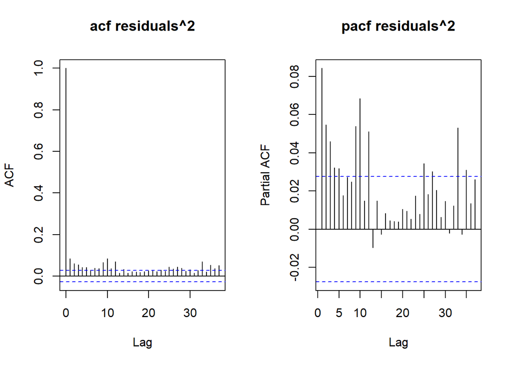

```r
par(mfrow=c(1,2))
acf(ar_model$residuals^2, main="acf residuals^2")
pacf(ar_model$residuals^2, main="pacf residuals^2")
```

```r
Box.test(ar_model$residuals^2, lag=20, fitdf=ar, type="Ljung-Box")
```

```
##
##  Box-Ljung test
##
## data:  ar_model$residuals^2
## X-squared = 215.54, df = 13, p-value < 2.2e-16
```

The results of the Ljung-Box test on the AR model’s squared residuals indicates that we should apply a GARCH model to the log returns, as there is still correlation among the squared terms.

```r
spec1 = ugarchspec(
  mean.model = list(armaOrder = c(ar,0)),
  variance.model = list(model = "sGARCH", garchOrder = c(1,1)),
  distribution.model = "norm")
m1 = ugarchfit(amd_return, spec=spec1)
m1
```

```
##
## *---------------------------------*
## *          GARCH Model Fit        *
## *---------------------------------*
##
## Conditional Variance Dynamics
## -----------------------------------
## GARCH Model  : sGARCH(1,1)
## Mean Model   : ARFIMA(7,0,0)
## Distribution : norm
##
## Optimal Parameters
## ------------------------------------
##         Estimate  Std. Error   t value Pr(>|t|)
## mu      0.000448    0.000519   0.86392 0.387633
## ar1     0.026621    0.015145   1.75771 0.078796
## ar2     0.018892    0.015142   1.24764 0.212163
## ar3    -0.015980    0.015093  -1.05877 0.289704
## ar4     0.004408    0.015092   0.29206 0.770242
## ar5     0.005031    0.015068   0.33386 0.738485
## ar6    -0.036341    0.015064  -2.41234 0.015850
## ar7     0.045022    0.015047   2.99199 0.002772
## omega   0.000015    0.000002   9.13892 0.000000
## alpha1  0.028166    0.001591  17.70613 0.000000
## beta1   0.962511    0.001051 915.52595 0.000000
##
## Robust Standard Errors:
##         Estimate  Std. Error   t value Pr(>|t|)
## mu      0.000448    0.000561   0.79815 0.424784
## ar1     0.026621    0.017306   1.53822 0.123994
## ar2     0.018892    0.015868   1.19059 0.233817
## ar3    -0.015980    0.015115  -1.05721 0.290415
## ar4     0.004408    0.015314   0.28782 0.773486
## ar5     0.005031    0.015867   0.31704 0.751210
## ar6    -0.036341    0.016635  -2.18455 0.028922
## ar7     0.045022    0.014700   3.06280 0.002193
## omega   0.000015    0.000005   2.95384 0.003138
## alpha1  0.028166    0.004845   5.81345 0.000000
## beta1   0.962511    0.001048 918.13541 0.000000
##
```

[output cut: 58 more lines]

```
## Negative Sign Bias  1.6954 0.09006   *
## Positive Sign Bias  0.9506 0.34184
## Joint Effect        4.0480 0.25633
##
##
## Adjusted Pearson Goodness-of-Fit Test:
## ------------------------------------
##   group statistic p-value(g-1)
## 1    20     299.7    2.303e-52
## 2    30     323.0    2.168e-51
## 3    40     334.2    1.464e-48
## 4    50     353.8    9.048e-48
##
##
## Elapsed time : 1.374806
```

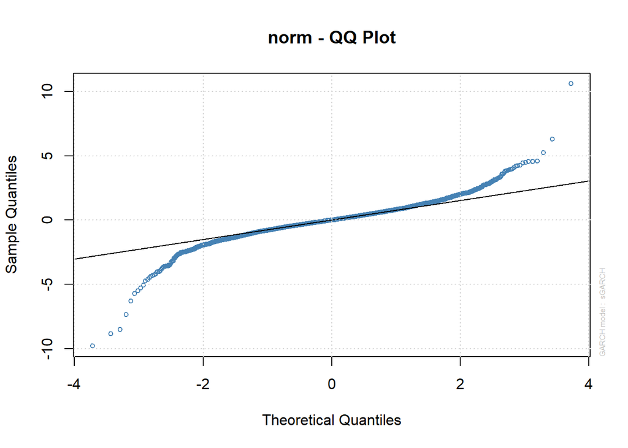

```r
plot(m1, which=9)
```

If we look at the norm - QQ Plot, we can see that we need to pick a distribution for our model with much heavier tails. I will try the “sstd”, or Skewed Student t-Distribution.

```r
spec2 = ugarchspec(
  mean.model = list(armaOrder = c(ar,0)),
  variance.model = list(model = "sGARCH", garchOrder = c(1,1)),
  distribution.model = "sstd")
m2 = ugarchfit(amd_return, spec=spec2)
m2
```

```
##
## *---------------------------------*
## *          GARCH Model Fit        *
## *---------------------------------*
##
## Conditional Variance Dynamics
## -----------------------------------
## GARCH Model  : sGARCH(1,1)
## Mean Model   : ARFIMA(7,0,0)
## Distribution : sstd
##
## Optimal Parameters
## ------------------------------------
##         Estimate  Std. Error  t value Pr(>|t|)
## mu      0.000619    0.000460  1.34503 0.178614
## ar1     0.035884    0.013474  2.66326 0.007739
## ar2     0.017408    0.012777  1.36254 0.173029
## ar3    -0.028367    0.012958 -2.18916 0.028585
## ar4     0.008460    0.013058  0.64786 0.517076
## ar5     0.004714    0.012799  0.36828 0.712662
## ar6    -0.020044    0.012587 -1.59243 0.111288
## ar7     0.012471    0.012752  0.97794 0.328102
## omega   0.000024    0.000026  0.94160 0.346397
## alpha1  0.053091    0.040584  1.30817 0.190814
## beta1   0.933086    0.054054 17.26218 0.000000
## skew    1.002111    0.018544 54.04053 0.000000
## shape   3.955982    0.224706 17.60511 0.000000
##
## Robust Standard Errors:
##         Estimate  Std. Error  t value Pr(>|t|)
## mu      0.000619    0.001136  0.54471 0.585956
## ar1     0.035884    0.014662  2.44743 0.014388
## ar2     0.017408    0.032433  0.53676 0.591435
## ar3    -0.028367    0.017868 -1.58760 0.112377
## ar4     0.008460    0.012719  0.66513 0.505965
## ar5     0.004714    0.017839  0.26423 0.791606
## ar6    -0.020044    0.021318 -0.94025 0.347091
## ar7     0.012471    0.012896  0.96698 0.333553
## omega   0.000024    0.000207  0.11648 0.907273
## alpha1  0.053091    0.323769  0.16398 0.869747
```

[output cut: 64 more lines]

```
## Negative Sign Bias  0.6960 0.4865
## Positive Sign Bias  0.2461 0.8056
## Joint Effect        0.7232 0.8677
##
##
## Adjusted Pearson Goodness-of-Fit Test:
## ------------------------------------
##   group statistic p-value(g-1)
## 1    20     19.95      0.39769
## 2    30     26.71      0.58725
## 3    40     57.86      0.02637
## 4    50     52.35      0.34545
##
##
## Elapsed time : 2.779261
```

```r
#coef(m2)
```

```
##
## please wait...calculating quantiles...
```

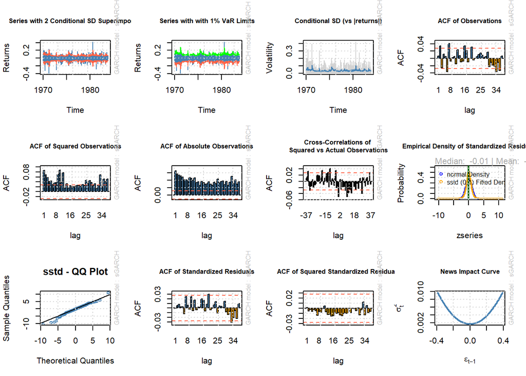

```r
plot(m2, which="all")
```

We know that it is common for stock volitility to be affected more from negative returns than positive returns. This is called ‘leverage effect’. The sGARCH model I have been using does not capture leverage effects, so to try to capture this, I will try using the eGARCH, or exponential GARCH.

```r
spec3 = ugarchspec(
  mean.model = list(armaOrder = c(ar,0)),
  variance.model = list(model = "eGARCH", garchOrder = c(1,1)),
  distribution.model = "sstd")
m3 = ugarchfit(amd_return, spec=spec3)
m3
```

```
##
## *---------------------------------*
## *          GARCH Model Fit        *
## *---------------------------------*
##
## Conditional Variance Dynamics
## -----------------------------------
## GARCH Model  : eGARCH(1,1)
## Mean Model   : ARFIMA(7,0,0)
## Distribution : sstd
##
## Optimal Parameters
## ------------------------------------
##         Estimate  Std. Error    t value Pr(>|t|)
## mu      0.000518    0.000456    1.13634 0.255816
## ar1     0.037316    0.012380    3.01422 0.002576
## ar2     0.016503    0.013224    1.24796 0.212045
## ar3    -0.027121    0.011838   -2.29104 0.021961
## ar4     0.008968    0.016926    0.52985 0.596215
## ar5     0.003613    0.003011    1.19988 0.230186
## ar6    -0.016203    0.022072   -0.73408 0.462897
## ar7     0.009110    0.012770    0.71340 0.475597
## omega  -0.087876    0.005379  -16.33650 0.000000
## alpha1 -0.008282    0.007982   -1.03752 0.299494
## beta1   0.986823    0.000787 1253.11128 0.000000
## gamma1  0.125623    0.014798    8.48897 0.000000
## skew    1.001646    0.018974   52.79023 0.000000
## shape   4.020817    0.232348   17.30514 0.000000
##
## Robust Standard Errors:
##         Estimate  Std. Error    t value Pr(>|t|)
## mu      0.000518    0.000513    1.00845 0.313237
## ar1     0.037316    0.018428    2.02496 0.042871
## ar2     0.016503    0.017717    0.93146 0.351615
## ar3    -0.027121    0.013853   -1.95784 0.050249
## ar4     0.008968    0.028071    0.31949 0.749356
## ar5     0.003613    0.002533    1.42644 0.153742
## ar6    -0.016203    0.041030   -0.39491 0.692911
## ar7     0.009110    0.013416    0.67908 0.497085
## omega  -0.087876    0.003698  -23.76505 0.000000
```

[output cut: 67 more lines]

```
## Negative Sign Bias  0.6457 0.5185
## Positive Sign Bias  0.3836 0.7013
## Joint Effect        1.0245 0.7953
##
##
## Adjusted Pearson Goodness-of-Fit Test:
## ------------------------------------
##   group statistic p-value(g-1)
## 1    20     18.22       0.5076
## 2    30     26.64       0.5911
## 3    40     36.16       0.6000
## 4    50     39.32       0.8369
##
##
## Elapsed time : 3.533782
```

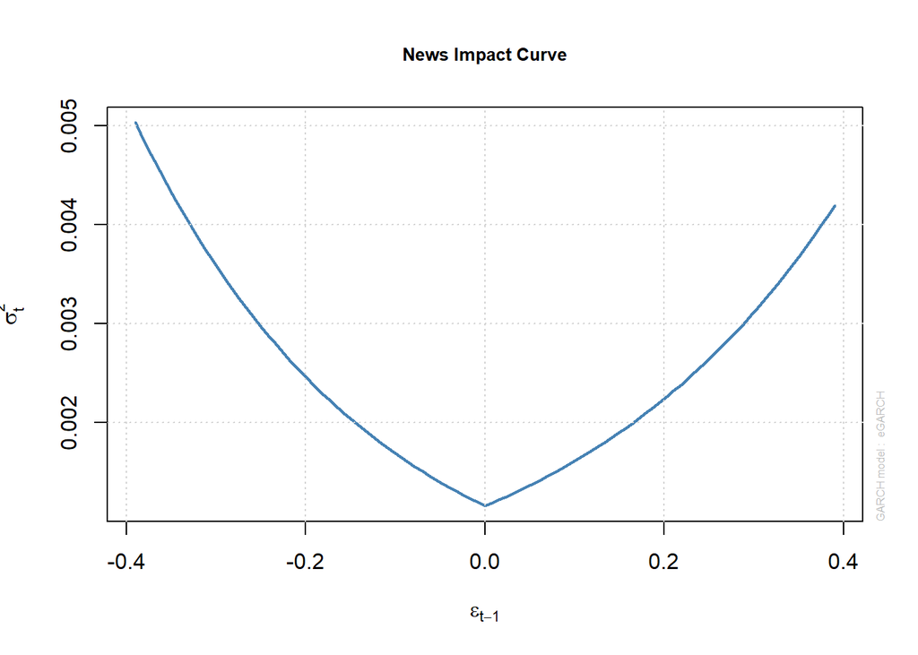

```r
plot(m3, which=12)
```

```
##
## please wait...calculating quantiles...
```

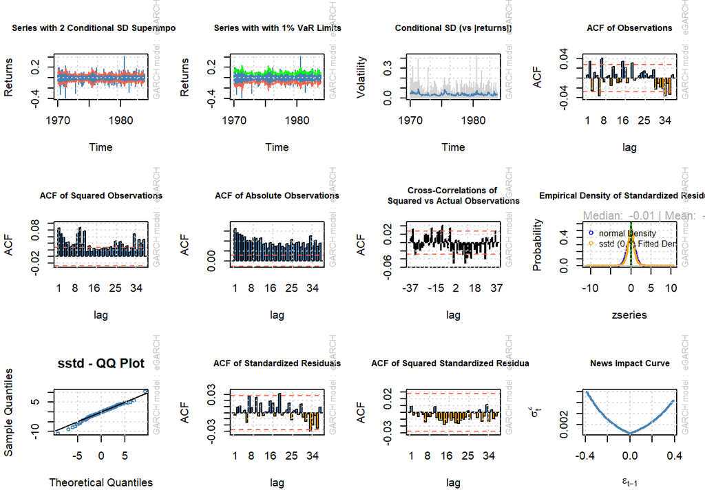

```r
plot(m3, which="all")
```

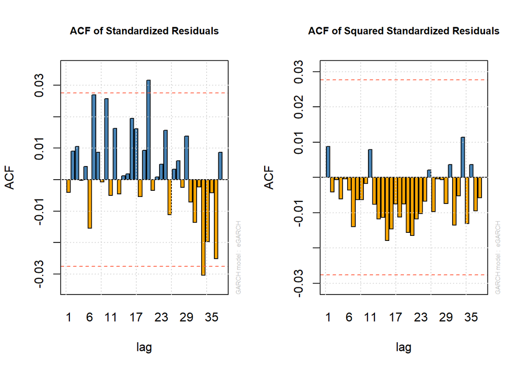

```r
par(mfrow=c(1,2))
plot(m3, which=10)
plot(m3, which=11)
```

```r
uncmean(m3)
```

```
## [1] 0.0005177646
```

```r
uncvariance(m3)
```

```
## [1] 0.001269549
```